# Whitewinequality

The dataset we are looking contains the large collection (about 5000) of white wines with their quality evaluated by experts together with various physical or chemical properties, such as density, pH, alcohol, etc.

The goal of this project is to analyze and understand this dataset

Loaing the Packages

Reading the wineQualityWhites file and finding the names of the file.

```r
wineQuality <-read.csv('wineQualityWhites.csv')
```

```r
names(wineQuality)
```

```
##  [1] "X"                    "fixed.acidity"        "volatile.acidity"
##  [4] "citric.acid"          "residual.sugar"       "chlorides"
##  [7] "free.sulfur.dioxide"  "total.sulfur.dioxide" "density"
## [10] "pH"                   "sulphates"            "alcohol"
## [13] "quality"
```

```r
#1.What is the summary of the winequality and viewing the dataset.
summary(wineQuality)
```

```
##        X        fixed.acidity    volatile.acidity  citric.acid
##  Min.   :   1   Min.   : 3.800   Min.   :0.0800   Min.   :0.0000
##  1st Qu.:1225   1st Qu.: 6.300   1st Qu.:0.2100   1st Qu.:0.2700
##  Median :2450   Median : 6.800   Median :0.2600   Median :0.3200
##  Mean   :2450   Mean   : 6.855   Mean   :0.2782   Mean   :0.3342
##  3rd Qu.:3674   3rd Qu.: 7.300   3rd Qu.:0.3200   3rd Qu.:0.3900
##  Max.   :4898   Max.   :14.200   Max.   :1.1000   Max.   :1.6600
##  residual.sugar     chlorides       free.sulfur.dioxide
##  Min.   : 0.600   Min.   :0.00900   Min.   :  2.00
##  1st Qu.: 1.700   1st Qu.:0.03600   1st Qu.: 23.00
##  Median : 5.200   Median :0.04300   Median : 34.00
##  Mean   : 6.391   Mean   :0.04577   Mean   : 35.31
##  3rd Qu.: 9.900   3rd Qu.:0.05000   3rd Qu.: 46.00
##  Max.   :65.800   Max.   :0.34600   Max.   :289.00
##  total.sulfur.dioxide    density             pH          sulphates
##  Min.   :  9.0        Min.   :0.9871   Min.   :2.720   Min.   :0.2200
##  1st Qu.:108.0        1st Qu.:0.9917   1st Qu.:3.090   1st Qu.:0.4100
##  Median :134.0        Median :0.9937   Median :3.180   Median :0.4700
##  Mean   :138.4        Mean   :0.9940   Mean   :3.188   Mean   :0.4898
##  3rd Qu.:167.0        3rd Qu.:0.9961   3rd Qu.:3.280   3rd Qu.:0.5500
##  Max.   :440.0        Max.   :1.0390   Max.   :3.820   Max.   :1.0800
##     alcohol         quality
##  Min.   : 8.00   Min.   :3.000
##  1st Qu.: 9.50   1st Qu.:5.000
##  Median :10.40   Median :6.000
##  Mean   :10.51   Mean   :5.878
##  3rd Qu.:11.40   3rd Qu.:6.000
##  Max.   :14.20   Max.   :9.000
```

### Univariate Plots Section

Lets see how the quality variable is distributed.

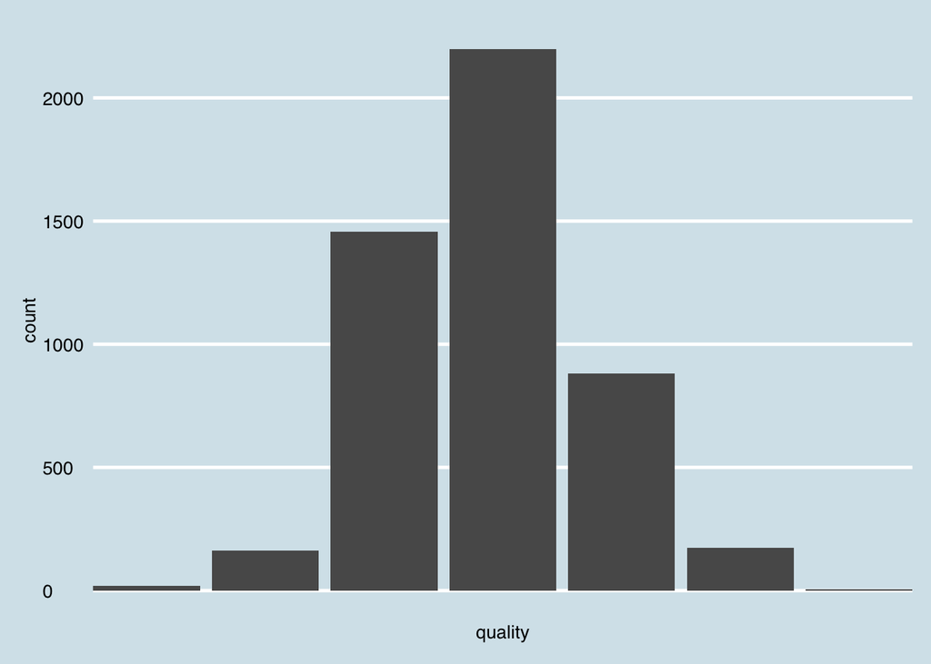

The quality variable has a large number of data with 5 and 6.The quality 3 and 9 have very few data.Lets count exactly how many observations are theer for each quality.

```r
#3)find the frequency of each type of quality

count(wineQuality,'quality')
```

```
##   quality freq
## 1       3   20
## 2       4  163
## 3       5 1457
## 4       6 2198
## 5       7  880
## 6       8  175
## 7       9    5
```

Lets see whats the datatype of each variable and how its distributed.So it can help us in choosing the binwidth and plotting more graph.

```r
#4)
str(wineQuality)
```

```
## 'data.frame':    4898 obs. of  13 variables:
##  $ X                   : int  1 2 3 4 5 6 7 8 9 10 ...
##  $ fixed.acidity       : num  7 6.3 8.1 7.2 7.2 8.1 6.2 7 6.3 8.1 ...
##  $ volatile.acidity    : num  0.27 0.3 0.28 0.23 0.23 0.28 0.32 0.27 0.3 0.22 ...
##  $ citric.acid         : num  0.36 0.34 0.4 0.32 0.32 0.4 0.16 0.36 0.34 0.43 ...
##  $ residual.sugar      : num  20.7 1.6 6.9 8.5 8.5 6.9 7 20.7 1.6 1.5 ...
##  $ chlorides           : num  0.045 0.049 0.05 0.058 0.058 0.05 0.045 0.045 0.049 0.044 ...
##  $ free.sulfur.dioxide : num  45 14 30 47 47 30 30 45 14 28 ...
##  $ total.sulfur.dioxide: num  170 132 97 186 186 97 136 170 132 129 ...
##  $ density             : num  1.001 0.994 0.995 0.996 0.996 ...
##  $ pH                  : num  3 3.3 3.26 3.19 3.19 3.26 3.18 3 3.3 3.22 ...
##  $ sulphates           : num  0.45 0.49 0.44 0.4 0.4 0.44 0.47 0.45 0.49 0.45 ...
##  $ alcohol             : num  8.8 9.5 10.1 9.9 9.9 10.1 9.6 8.8 9.5 11 ...
##  $ quality             : int  6 6 6 6 6 6 6 6 6 6 ...
```

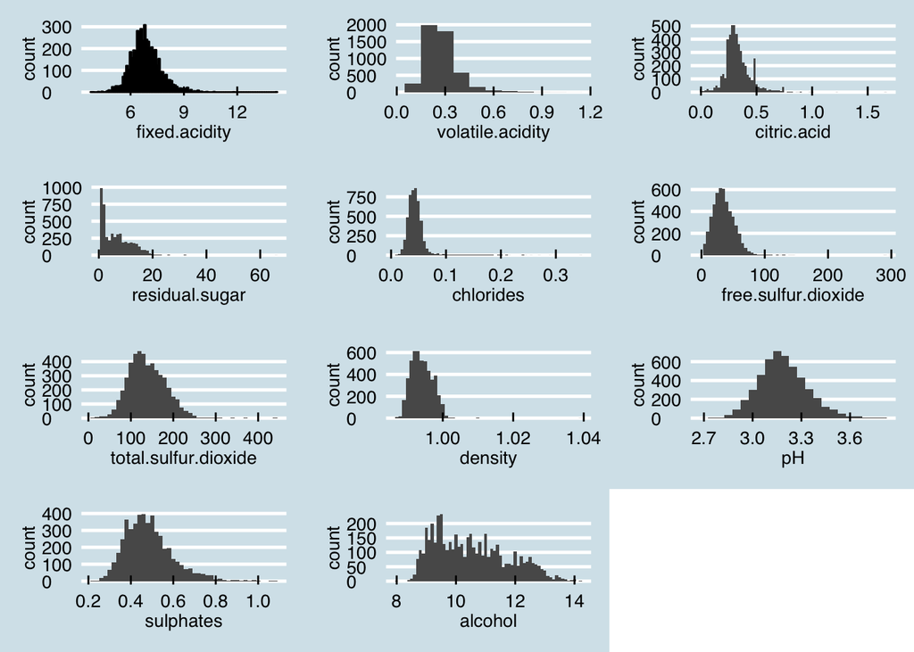

The attributes fixedacidity,volatile.acidity,citric.acid,chlorides have outliers.

For the residual sugar lets change binwidth and see how the graph changes.

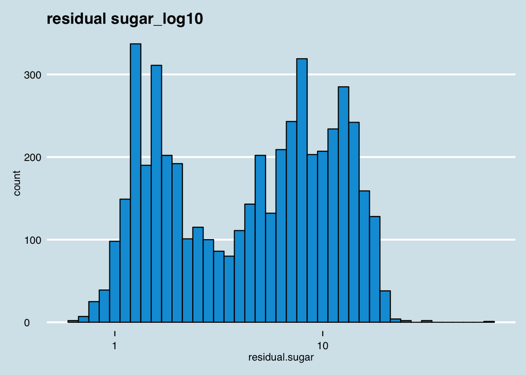

Lets change the binwidth of the alcohol variable and see how the graph changes.

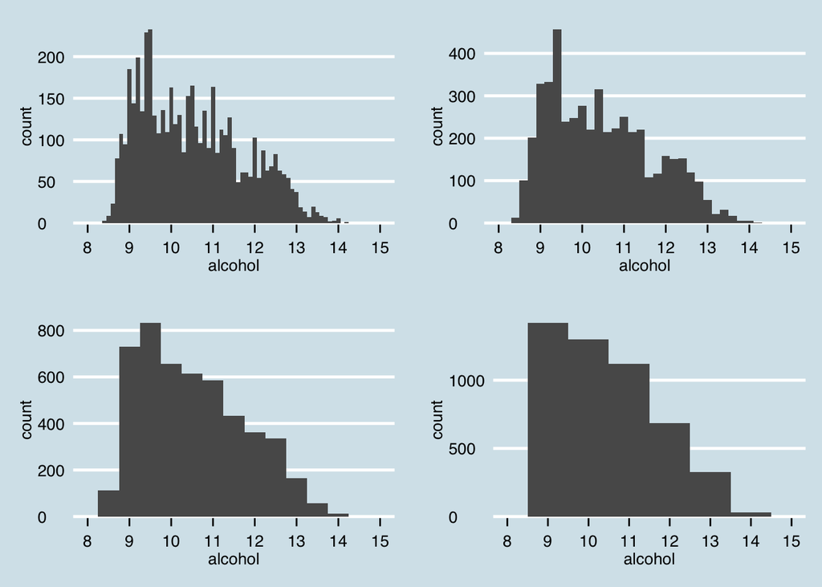

```
##    Min. 1st Qu.  Median    Mean 3rd Qu.    Max.
##    8.00    9.50   10.40   10.51   11.40   14.20
```

We can look at data with different “resolution”. At the coarse level (binwidth=1), we see that it follows a skewed distribution with most number of samples in the range 9,10. At the fine level (binwidth=0.1), we see more irregularities of the distribution with multiple spikes.

Let us give a rating for the quality variable poor good and best and use that for our analysis.

```
## poor good best
## 1640 3078  180
```

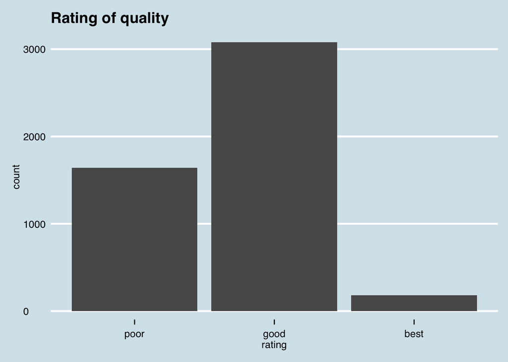

### Univariate Analysis

##### What is the structure of your dataset?

There are 4,898 white wine observations and 13 variables in the dataset.x is numeric variable and with 11 quantitative features (fixed acidity, volatile acidity, citric acid, residual sugar, chlorides, free sulfur dioxide, total sulfur dioxide, density, pH, sulphates, and alcohol).The Output variable is quality and can be considered an ordered factor because it scores the wine from 0 to 10 with 10 being the best.

The density has the small range from 0.9871 to 1.0390,sulphates also has small range 0.22 to 1.080.While total sulfur dioxide has huge range from 9 to 440.0 and free sulfur range from 2 to 289.

##### What is/are the main feature(s) of interest in your dataset?

The main feature of my inetrest in the data is quality. I’d like to analyse which features determine the quality of wines.

##### What other features in the dataset do you think will help support your investigation into your feature(s) of interest?

Features such as residual.sugar, sulphates, pH, chlorides will likely contribute to the wine quality and will support our investigation.

##### Did you create any new variables from existing variables in the dataset?

I created a rating variable to improve the later visualizations.

##### Of the features you investigated, were there any unusual distributions? Did you perform any operations on the data to tidy, adjust, or change the form of the data? If so, why did you do this?

One of the first adjustments I made to the data was to change the data type of quality to be an ordered factor. It can be analyzed more naturally in this way because the quality ratings can be thought of as discrete levels. This also preps it for future analysis such as box plots.

The residual sugar histogram was the only histogram that did not look normal because it was too long-tailed, so I applied a log transform to the x-axis. As expected, the distribution became more normal, but it also took on a bimodal shape. This means that the measurements for residual sugar loosely group together at a lower value and a higher value. This may have an impact on the quality and warrants further investigation.

### Bivariate analysis

Let us analyze all of the variables using ggpairs in order to quickly take a look.I used all 4,898 observations in this analysis.

Lets us plot each of the attributes against other attribute and find correlation between them.

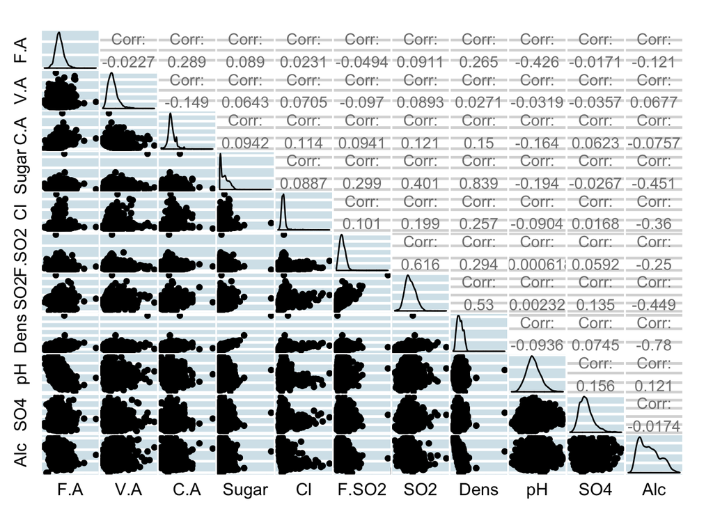

Not all correlations are strong.Quality is correlated to so2,ph,density and alcohol.There could be other correaltions too.But I feel these to be interesting to analyse.

```r
cor(wineQuality[,2:12], wineQuality$numeric.quality)
```

[output not shown]

Since we are interested in how quality is affected with other factor variable.Lets plot some of the factor variable to check how qulaity is affected with respect to each of them.

First lets us start with the alcohol content in wines and the qulaity.

#### Alcohol and Quality

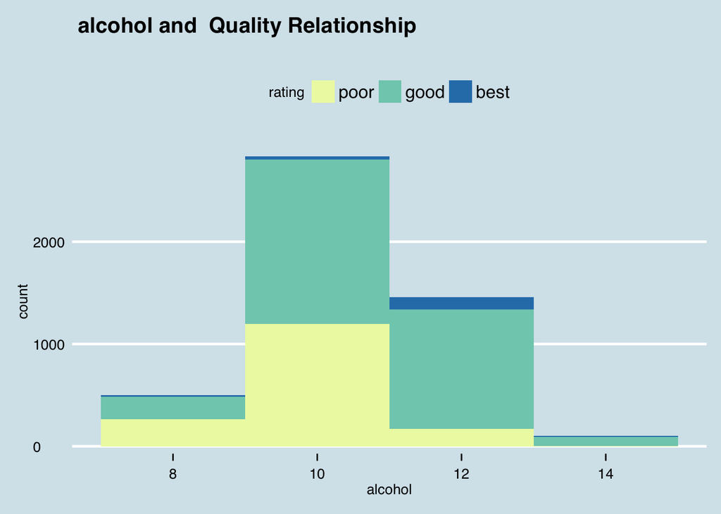

This shows that the alcohol content in wine changes its quality.We can see that the alcohol content with more than 13 has good and best quality wines.and poor quality wines have less or moderate alcohol content.

#### free So2 and quality relationship

The So2 is added as preservatives for the wines.It would be interesting to check the so2 distribution with quality.

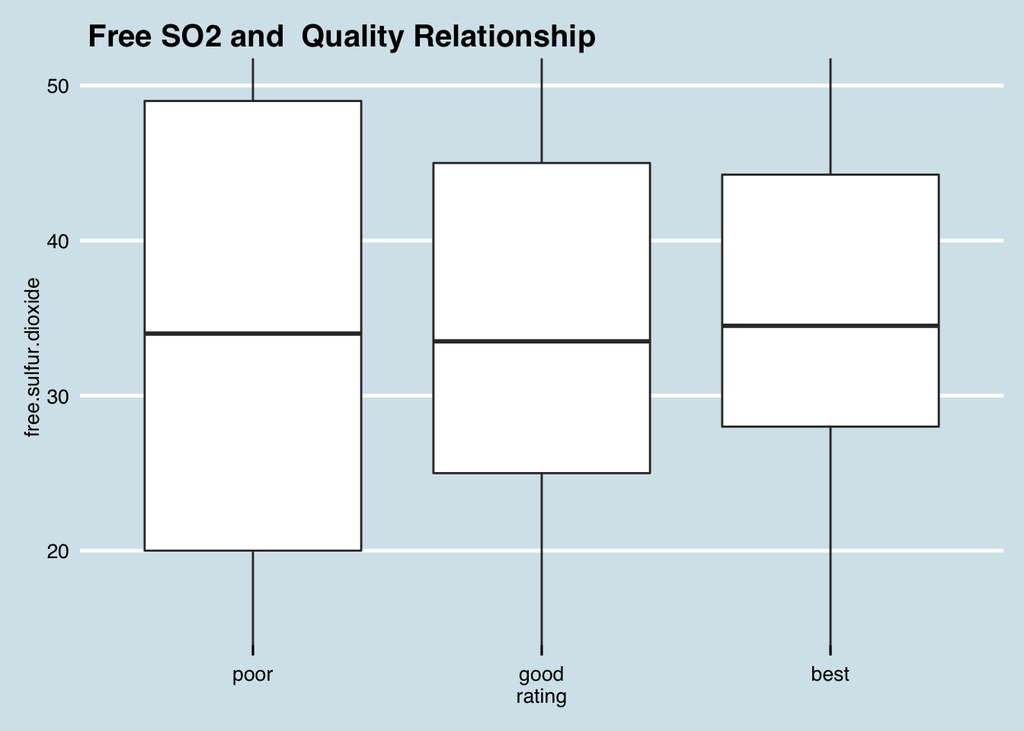

#### total So2 and quality relationship

Lets check how total SO2 is related to Quality

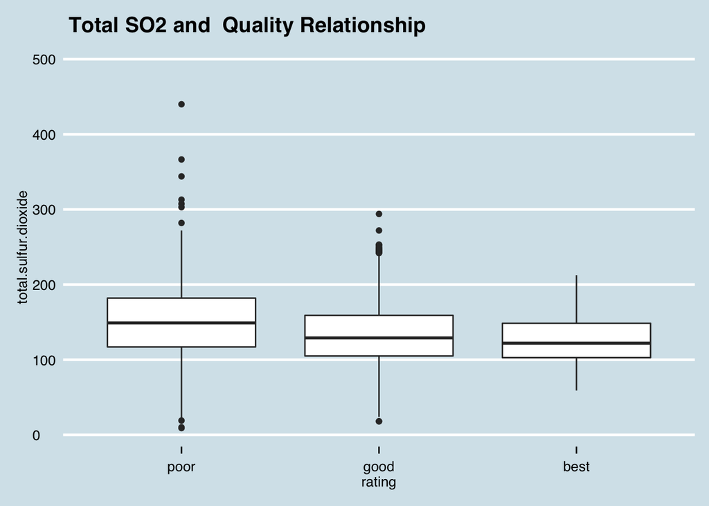

It would not be a surprise that if free so2 affects the quality total so2 will also affect the quality.The plots show that total So2 dereases with increasing Rating of Quality.The best wines have very less total so2 in it.

#### Alcohol and density

The alcohol has less density than water,lets check how it affects the alcohol.

```
## Correlation:  -0.7801376
```

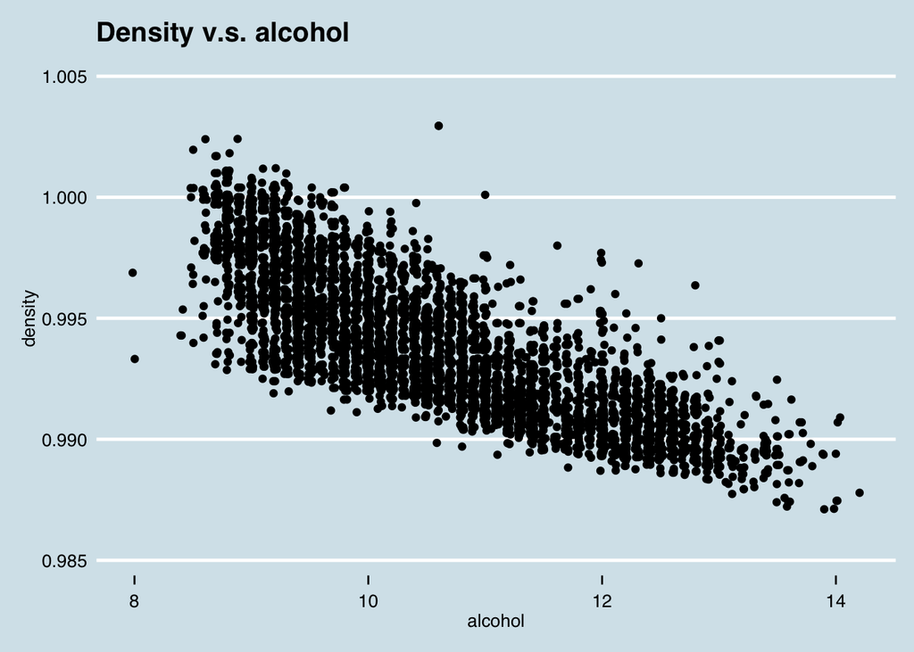

Its so obvious from the graph that the density decreases with high alcohol.As alcohol is less desnser than that of water.It also has a negative correlation.

What happens to quality when pH values are plotted against it.

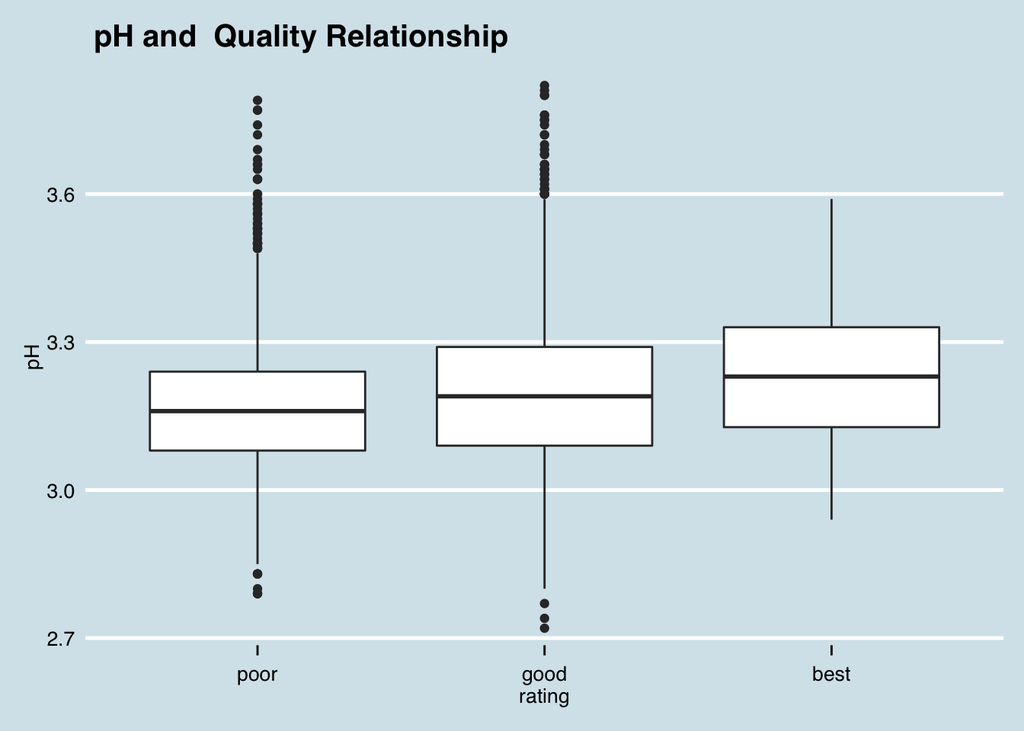

The plot shows that most wines fall into range of 3.1-3.3 pH.However the best quality wines go slightly higher than 3.3pH.Lets look closer.

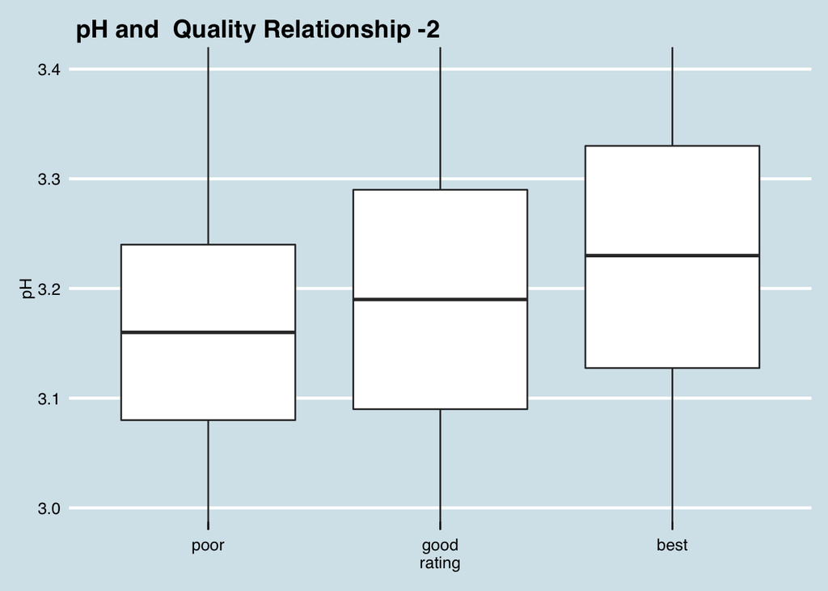

The best Quality wines have higher p?h values compared to that of the other qualities.pH values are also important in the quality of wines.

#### Bivariate analysis

##### Talk about some of the relationships you observed in this part of the investigation. How did the feature(s) of interest vary with other features in the dataset?

We can see that there is a clear dependency between alcohol and quality.

Its seen that the highest quality wine has quite concentrated alcohol level, in other words, the variance of alcohol level for wine of this quality is low.

The quality also has some dependency towrds pH.The pH levels were high for high quality wines.But there were some outliers which had high pH for poor quality wines.So need a bettr model to know more about it.

#### Did you observe any interesting relationships between the other features (not the main feature(s) of interest)?

The residual sugar and density are correlated.Similarly the density and alcohol also had high negative correlation.

#### Multivariate analysis

We have not checke dthe sulphates with the quality in the bivariate lets do that and take alcohol with it and see how the sulphates and alcohol do with the quality of the wine.

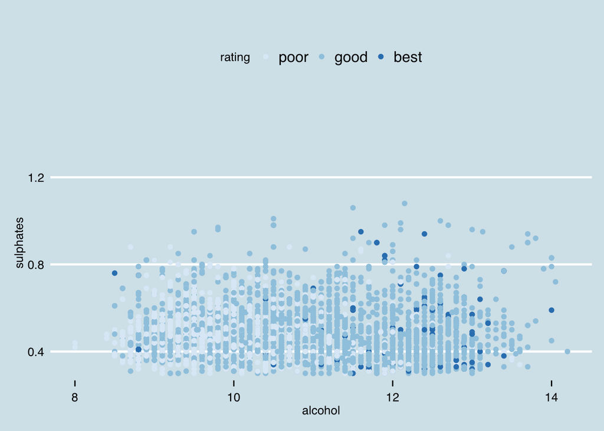

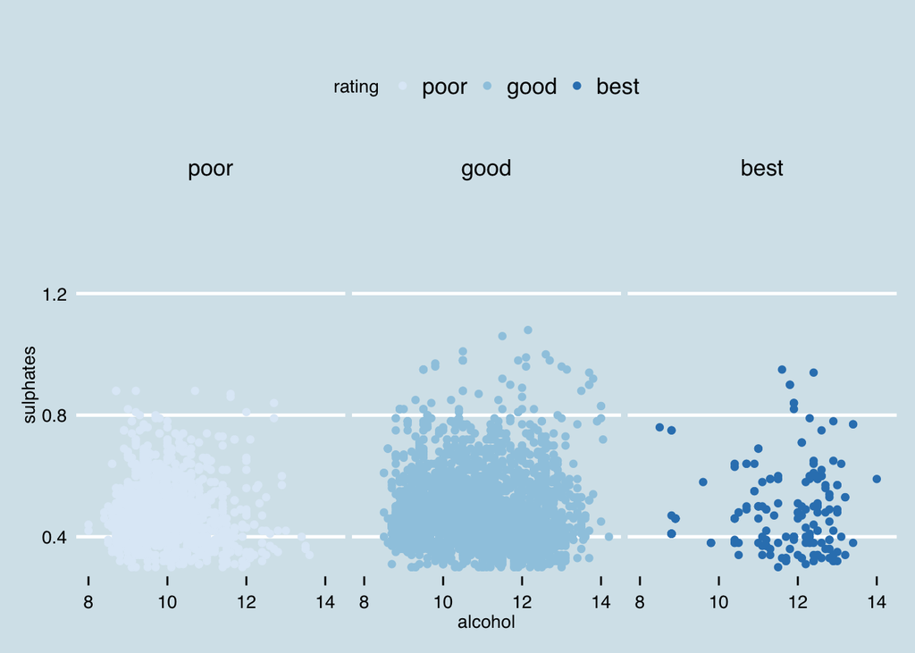

```
## $title
## [1] "sulphates,Quality and alcohol"
##
## attr(,"class")
## [1] "labels"
```

Lets take a closer look into the residual ,alcohol and Qulaity of the wines.

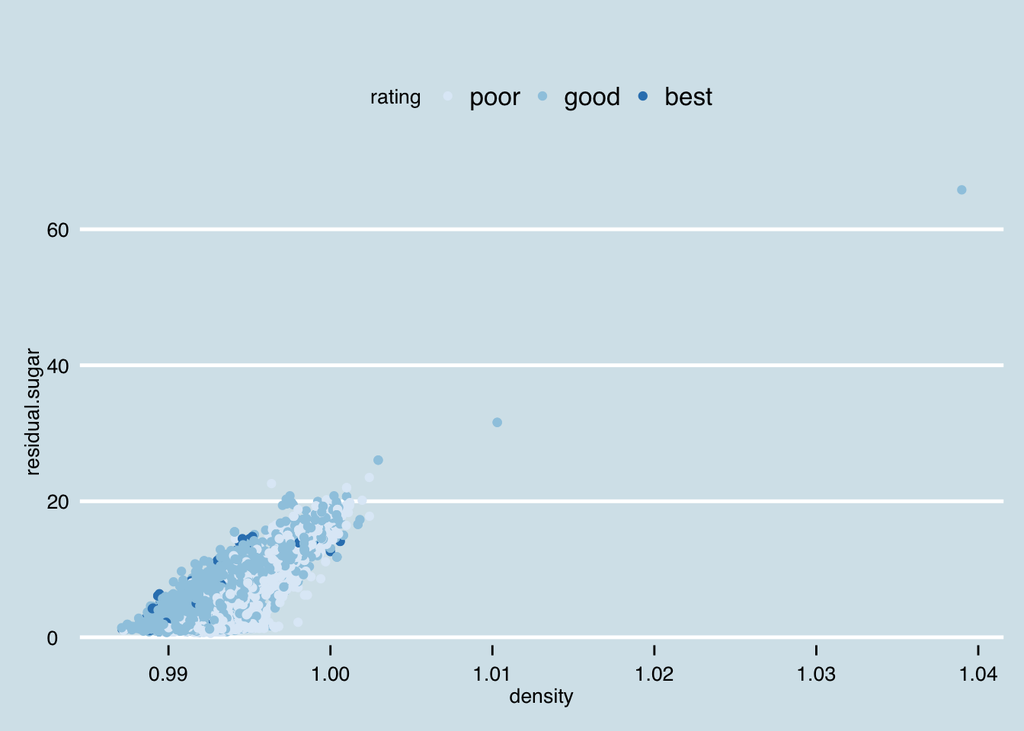

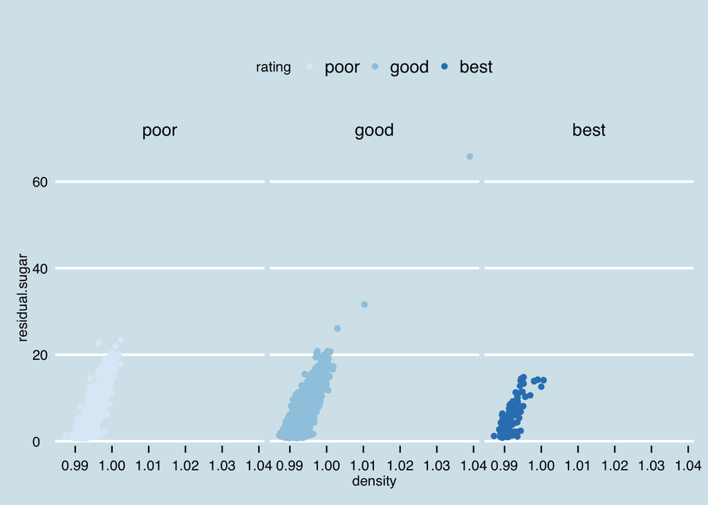

```
## $title
## [1] "residualsugar,Quality and density"
##
## attr(,"class")
## [1] "labels"
```

#### Multiplevariate analysis

##### Were there any interesting or surprising interactions between features?

From very early on in the analysis, I found it surprising that alcohol is positively correlated with the quality.

### Final plots and summary

#### Plot One

The wine qulaity had a range from 3 to 9.But the data for the qualities 3 and 9 were very less.There are very few data variables with best quality wine 9.So combined few more data like the quality 8 to make a better sample for comparison.Quality of 3,4 and 5 comes under poor and quality 6 and 7 comes under good and the rest comes under best.I thought of categorising the qulaity variable into rating.

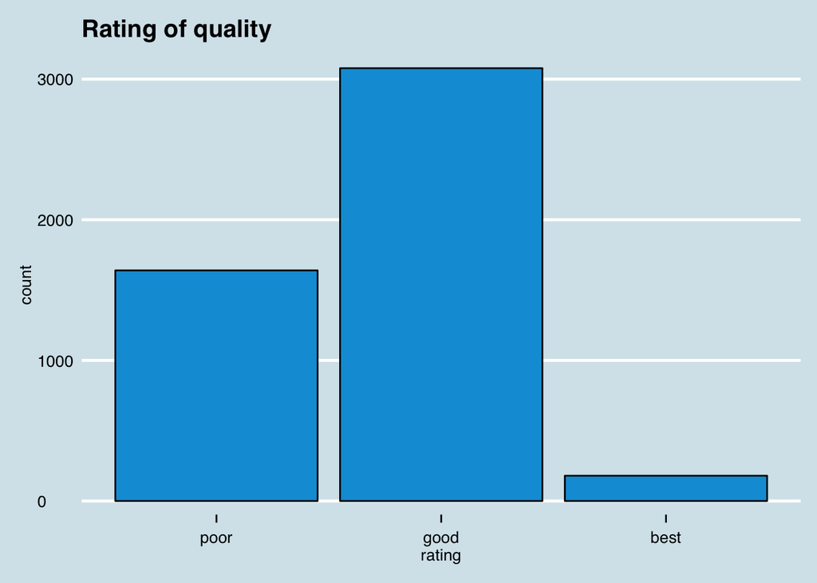

This plot shows the categorized poor,good and best quality wines.The good quality wines are more than the best wines.The poor quality wines are more than best but less than the good quality wines.

#### Plot Two

While creating ggpairs found some correlaton between total So2 and the wine density.Lets us draw a plot and analyse it.

[figure not shown]

#### Plot three

The density and alcohol correlated to each from the EDA we did.Lets us plot some different graph to see their distribution.

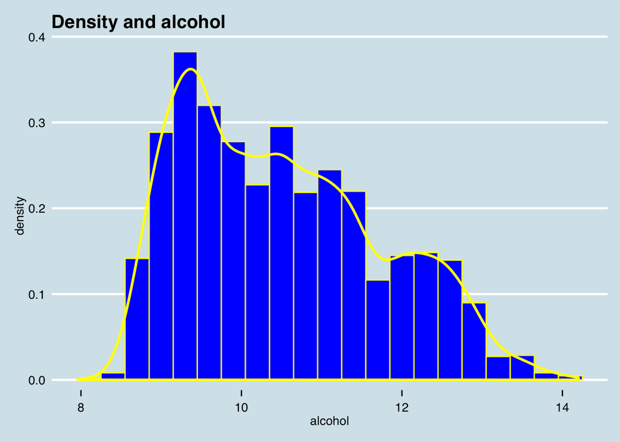

### Reflection and Future analysis

Having a reasonable size for the dataset is important. When there are too few number of data point, the statistical analysis might be less reliable.There were very less just 5 samples with quality 9.So had to group that with quality 8 to make a better sample.

This course and exercise helped how to explore data. It was fun learning new tools in R to explore any set of data.I have got basic knowledge with plotting, including scatterplots, histograms, boxplots, and line graphs, while adjusting a multitude of parameters throughout my charts, such as transparency, jitter, smoothing, labeling, limiting axes, and facet wrapping. Finding a good model and analysis is really hard and I realized that the more trial and error I did, usually the more I can make sense of the data and find interesting trends from it.

In future I would like to spend more time on some linear models and go in depth into correlation of the two variables.This was really inetresting to work with new dataset and variables.

```r
####[ http://www3.dsi.uminho.pt/pcortez/wine5.pdf]
####[//s3.amazonaws.com/udacity-hosted-downloads/ud651/wineQualityInfo.txt]
```